# Assignment 6

This week’s involves transforming two data sets in order to ask a specific question of each. The first is a more complete set of data on the number of new tuberculosis cases each year from 1980 to 2013 in 219 countries, taken from the [World Health Organization Global Tuberculosis Report](https://www.who.int/health-topics/tuberculosis).

For the second “real world” example we return to the METABRIC data set and introduce the other set of assay data obtained as part of the original 2012 study that concerns genomic copy number. We’ll transform the copy number data downloaded from [cBioPortal](https://www.cbioportal.org/study/summary?id=brca_metabric) so that we can look at the copy number states for some of our favourite genes and then combine that with the expression data to see how copy number influences gene expression.

The clinical data, gene expression values and mutation data were all downloaded from [cBioPortal](https://www.cbioportal.org/study/summary?id=brca_metabric).

```r
library(tidyverse)
```

**1. Tidy the WHO tuberculosis data set**

In this week’s materials we demonstrated the restructuring of different representations of a very small subset of the WHO tuberculosis data set (tables 1 to 4a and b). The more complete data set is also available in its original format in another data frame available as part of the **tidyr** package, named `who`.

```r
who
```

```
## # A tibble: 7,240 x 60
##    country iso2  iso3   year new_sp_m014 new_sp_m1524 new_sp_m2534
##    <chr>   <chr> <chr> <int>       <int>        <int>        <int>
##  1 Afghan… AF    AFG    1980          NA           NA           NA
##  2 Afghan… AF    AFG    1981          NA           NA           NA
##  3 Afghan… AF    AFG    1982          NA           NA           NA
##  4 Afghan… AF    AFG    1983          NA           NA           NA
##  5 Afghan… AF    AFG    1984          NA           NA           NA
##  6 Afghan… AF    AFG    1985          NA           NA           NA
##  7 Afghan… AF    AFG    1986          NA           NA           NA
##  8 Afghan… AF    AFG    1987          NA           NA           NA
##  9 Afghan… AF    AFG    1988          NA           NA           NA
## 10 Afghan… AF    AFG    1989          NA           NA           NA
## # … with 7,230 more rows, and 53 more variables: new_sp_m3544 <int>,
## #   new_sp_m4554 <int>, new_sp_m5564 <int>, new_sp_m65 <int>,
## #   new_sp_f014 <int>, new_sp_f1524 <int>, new_sp_f2534 <int>,
## #   new_sp_f3544 <int>, new_sp_f4554 <int>, new_sp_f5564 <int>,
## #   new_sp_f65 <int>, new_sn_m014 <int>, new_sn_m1524 <int>,
## #   new_sn_m2534 <int>, new_sn_m3544 <int>, new_sn_m4554 <int>,
## #   new_sn_m5564 <int>, new_sn_m65 <int>, new_sn_f014 <int>,
## #   new_sn_f1524 <int>, new_sn_f2534 <int>, new_sn_f3544 <int>,
## #   new_sn_f4554 <int>, new_sn_f5564 <int>, new_sn_f65 <int>,
## #   new_ep_m014 <int>, new_ep_m1524 <int>, new_ep_m2534 <int>,
## #   new_ep_m3544 <int>, new_ep_m4554 <int>, new_ep_m5564 <int>,
## #   new_ep_m65 <int>, new_ep_f014 <int>, new_ep_f1524 <int>,
## #   new_ep_f2534 <int>, new_ep_f3544 <int>, new_ep_f4554 <int>,
## #   new_ep_f5564 <int>, new_ep_f65 <int>, newrel_m014 <int>,
## #   newrel_m1524 <int>, newrel_m2534 <int>, newrel_m3544 <int>,
## #   newrel_m4554 <int>, newrel_m5564 <int>, newrel_m65 <int>,
## #   newrel_f014 <int>, newrel_f1524 <int>, newrel_f2534 <int>,
## #   newrel_f3544 <int>, newrel_f4554 <int>, newrel_f5564 <int>,
## #   newrel_f65 <int>
```

What are the variables in this data set?

Create a bulleted list with your answer here.

- country
- iso2 and iso3 country codes
- year
- gender
- age group
- diagnosis method

*Hint: see the help page for `who` to understand the meaning of the column headings.*

*Hint: the Markdown Quick Reference available from the Help menu in RStudio is a very useful guide to formatting text in R markdown documents.*

Why isn’t this data set tidy and what kinds of analysis are not straightforward with the data in this format?

Transform the data into a tidy format.

Columns `new_sp_m014` to `newrel_f65` are values for a compound variable, i.e. multiple variables joined together - the restructured data frame should have columns for each of the separated values in these column headings.

Remove all rows with missing values for the number of tuberculosis cases.

```r
who %>%
  pivot_longer(starts_with("new"), names_to = "group", values_to = "cases", values_drop_na = TRUE) %>%
  mutate(group = str_remove(group, "new")) %>%
  count(group)
```

```
## # A tibble: 56 x 2
##    group         n
##    <chr>     <int>
##  1 _ep_f014   1032
##  2 _ep_f1524  1021
##  3 _ep_f2534  1021
##  4 _ep_f3544  1021
##  5 _ep_f4554  1017
##  6 _ep_f5564  1017
##  7 _ep_f65    1014
##  8 _ep_m014   1038
##  9 _ep_m1524  1026
## 10 _ep_m2534  1020
## # … with 46 more rows
```

```r
who_tidy <- who %>%
  pivot_longer(starts_with("new"), names_to = "group", values_to = "cases") %>%
  mutate(group = str_remove(group, "new_")) %>%
  mutate(group = str_remove(group, "new")) %>%
  separate(group, into = c("diagnosis", "group"), sep = "_") %>%
  separate(group, into = c("gender", "age_group"), sep = 1) %>%
  filter(!is.na(cases))

# remove missing values as part of the pivot and use regular expression magic
who_tidy <- who %>%
  pivot_longer(starts_with("new"), names_to = "group", values_to = "cases", values_drop_na = TRUE) %>%
  mutate(group = str_remove(group, "^new_?")) %>%
  separate(group, into = c("diagnosis", "group"), sep = "_") %>%
  separate(group, into = c("gender", "age_group"), sep = 1)

who_tidy
```

```
## # A tibble: 76,046 x 8
##    country     iso2  iso3   year diagnosis gender age_group cases
##    <chr>       <chr> <chr> <int> <chr>     <chr>  <chr>     <int>
##  1 Afghanistan AF    AFG    1997 sp        m      014           0
##  2 Afghanistan AF    AFG    1997 sp        m      1524         10
##  3 Afghanistan AF    AFG    1997 sp        m      2534          6
##  4 Afghanistan AF    AFG    1997 sp        m      3544          3
##  5 Afghanistan AF    AFG    1997 sp        m      4554          5
##  6 Afghanistan AF    AFG    1997 sp        m      5564          2
##  7 Afghanistan AF    AFG    1997 sp        m      65            0
##  8 Afghanistan AF    AFG    1997 sp        f      014           5
##  9 Afghanistan AF    AFG    1997 sp        f      1524         38
## 10 Afghanistan AF    AFG    1997 sp        f      2534         36
## # … with 76,036 more rows
```

*Hint 1: the column headers from new_sp_m014 onwards contain a superfluous prefix “new” or “new_” that you will want to remove; this can be done using one of the stringr functions in a single step if you know about regular expressions but is also achievable in two steps if you don’t use any regular expression magic.*

*Hint 2: separating two of the variables is a bit tricky because there is no separator character; try looking at the help for the separate function to see how this can be done.*

**2. Recreate `table1` from your tidy version of the WHO tuberculosis data set**

Recreate the first 3 columns of `table1`, containing a small subset of the WHO tuberculosis data set, from your tidy version of `who`.

```r
select(table1, 1:3)
```

```
## # A tibble: 6 x 3
##   country      year  cases
##   <chr>       <int>  <int>
## 1 Afghanistan  1999    745
## 2 Afghanistan  2000   2666
## 3 Brazil       1999  37737
## 4 Brazil       2000  80488
## 5 China        1999 212258
## 6 China        2000 213766
```

```r
who_tidy %>%
  filter(country %in% c("Afghanistan", "Brazil", "China")) %>%
  filter(year %in% c(1999, 2000)) %>%
  group_by(country, year) %>%
  summarise(cases = sum(cases))
```

```
## # A tibble: 6 x 3
## # Groups:   country [3]
##   country      year  cases
##   <chr>       <int>  <int>
## 1 Afghanistan  1999    745
## 2 Afghanistan  2000   2666
## 3 Brazil       1999  37737
## 4 Brazil       2000  80488
## 5 China        1999 212258
## 6 China        2000 213766
```

*Hint: this will involve some filtering, grouping and summarization.*

**3. Create time series plots for cases of tuberculosis**

Create a time series plot showing the number of tuberculosis cases in the United Kingdom with separate lines for each age group. The year should be on the x axis and the number of cases on the y axis.

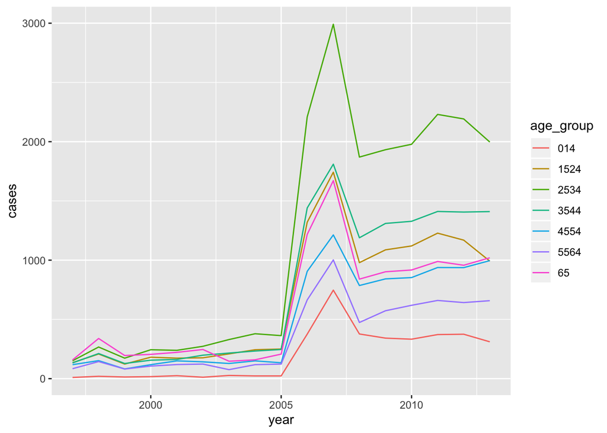

```r
who_tidy <- who_tidy %>%
  group_by(country, year, age_group) %>%
  summarise(cases = sum(cases))

who_tidy %>%
  filter(country == "United Kingdom of Great Britain and Northern Ireland") %>%
  ggplot() +
  geom_line(mapping = aes(x = year, y = cases, colour = age_group))
```

*Hint: we’re not distinguishing between genders in this plot so you’ll need the data to be summarized in the same way as the previous question.*

Use faceting in ggplot2 to create a series of plots showing the same information for France, Brazil, Japan and Uganda.

The numbers of cases in these countries are on quite different scales. Look at help page for `facet_wrap()` and try changing the `scales` argument so we can more easily compare the overall patterns between countries.

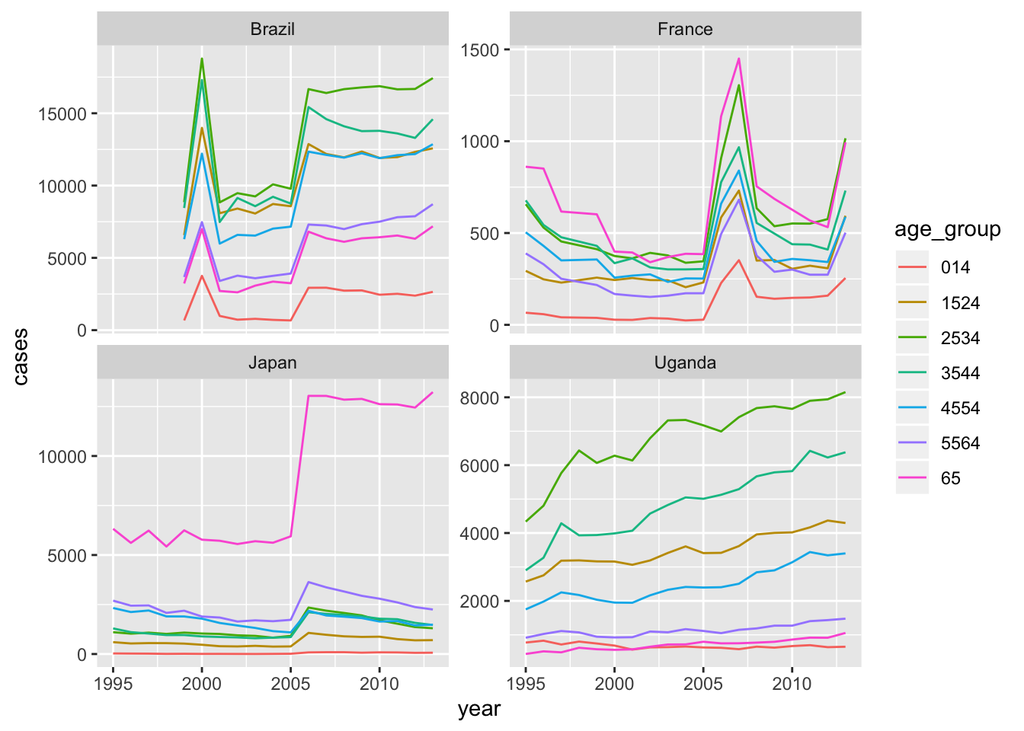

```r
who_tidy %>%
  filter(country %in% c("France", "Brazil", "Japan", "Uganda")) %>%
  ggplot() +
  geom_line(mapping = aes(x = year, y = cases, colour = age_group)) +
  facet_wrap(vars(country), scales = "free_y")
```

**4. Relate METABRIC copy number and expression data**

For this exercise we’ll read in the METABRIC mRNA expression data and copy number states into separate data frames. The aim is to see how the gene expression is affected by the copy number state of various genes through a series of box plot.

```r
expression <- read_tsv("metabric_mrna_expression.txt")
```

The expression data is in a matrix-like format with a row for each sample and a column for each gene. This is the format used when downloading data from [cBioPortal](https://www.cbioportal.org/study/summary?id=brca_metabric) after selecting a set of genes.

```r
expression
```

```
## # A tibble: 2,509 x 10
##    STUDY_ID      SAMPLE_ID  ESR1 ERBB2   PGR  TP53 PIK3CA GATA3 FOXA1  MLPH
##    <chr>         <chr>     <dbl> <dbl> <dbl> <dbl>  <dbl> <dbl> <dbl> <dbl>
##  1 brca_metabric MB-0000    8.93  9.33  5.68  6.34   5.70  6.93  7.95  9.73
##  2 brca_metabric MB-0002   10.0   9.73  7.51  6.19   5.76 11.3  11.8  12.5
##  3 brca_metabric MB-0005   10.0   9.73  7.38  6.40   6.75  9.29 11.7  10.3
##  4 brca_metabric MB-0006   10.4  10.3   6.82  6.87   7.22  8.67 11.9  10.5
##  5 brca_metabric MB-0008   11.3   9.96  7.33  6.34   5.82  9.72 11.6  12.2
##  6 brca_metabric MB-0010   11.2   9.74  5.95  5.42   6.12  9.79 12.1  11.4
##  7 brca_metabric MB-0014   10.8   9.28  7.72  5.99   7.48  8.37 11.5  10.8
##  8 brca_metabric MB-0020   NA    NA    NA    NA     NA    NA    NA    NA
##  9 brca_metabric MB-0022   10.4   8.61  5.59  6.17   7.59  7.87 10.7   9.95
## 10 brca_metabric MB-0025   NA    NA    NA    NA     NA    NA    NA    NA
## # … with 2,499 more rows
```

Convert this data frame into a tidy format with a row-per-sample-per-gene. Remove the rather uninteresting `STUDY_ID` column and filter out missing expression values (for those samples that weren’t assayed).

```r
expression <- expression %>%
  pivot_longer(ESR1:MLPH, names_to = "Gene", values_to = "Expression", values_drop_na = TRUE) %>%
  select(-STUDY_ID)
expression
```

```
## # A tibble: 15,232 x 3
##    SAMPLE_ID Gene   Expression
##    <chr>     <chr>       <dbl>
##  1 MB-0000   ESR1         8.93
##  2 MB-0000   ERBB2        9.33
##  3 MB-0000   PGR          5.68
##  4 MB-0000   TP53         6.34
##  5 MB-0000   PIK3CA       5.70
##  6 MB-0000   GATA3        6.93
##  7 MB-0000   FOXA1        7.95
##  8 MB-0000   MLPH         9.73
##  9 MB-0002   ESR1        10.0
## 10 MB-0002   ERBB2        9.73
## # … with 15,222 more rows
```

The copy number data are also in a matrix-like format but this time we have a row for each gene and a column for each sample. It is a very wide table containing 2175 columns (only the first 10 displayed below). This is the format of the copy number table you obtain if you download the complete METABRIC dataset from cBioPortal. The table read in is a subset containing rows for the 8 genes we’ve been using up till now.

```r
copy_number_states <- read_tsv("metabric_cna.txt")
select(copy_number_states, 1:10)
```

```
## # A tibble: 8 x 10
##   Hugo_Symbol Entrez_Gene_Id `MB-0000` `MB-0039` `MB-0045` `MB-0046`
##   <chr>                <dbl>     <dbl>     <dbl>     <dbl>     <dbl>
## 1 ERBB2                 2064         0         0         0         2
## 2 ESR1                  2099         0         0        -1         0
## 3 FOXA1                 3169         0         0         0         0
## 4 GATA3                 2625         0         0         0         0
## 5 MLPH                 79083         0         0         0         0
## 6 PGR                   5241         0        -1         0         0
## 7 PIK3CA                5290         0         0         2         0
## 8 TP53                  7157         0         0        -1        -1
## # … with 4 more variables: `MB-0048` <dbl>, `MB-0050` <dbl>,
## #   `MB-0053` <dbl>, `MB-0062` <dbl>
```

Convert this data frame into a tidy format with a row-per-sample-per-gene where the values are the copy number states:

- -2 deletion
- -1 loss
- 0 neutral
- 1 gain
- 2 amplification

Remove the `Entrez_Gene_id` column and convert the copy number state variable into a factor.

```r
copy_number_states <- copy_number_states %>%
  pivot_longer(3:2175, names_to = "Sample", values_to = "Copy_number_state") %>%
  select(-Entrez_Gene_Id) %>%
  mutate(Copy_number_state = as_factor(Copy_number_state))
copy_number_states
```

```
## # A tibble: 17,384 x 3
##    Hugo_Symbol Sample  Copy_number_state
##    <chr>       <chr>   <fct>
##  1 ERBB2       MB-0000 0
##  2 ERBB2       MB-0039 0
##  3 ERBB2       MB-0045 0
##  4 ERBB2       MB-0046 2
##  5 ERBB2       MB-0048 2
##  6 ERBB2       MB-0050 -1
##  7 ERBB2       MB-0053 0
##  8 ERBB2       MB-0062 -1
##  9 ERBB2       MB-0064 0
## 10 ERBB2       MB-0066 0
## # … with 17,374 more rows
```

Count the total number of occurrences of each copy number state.

```r
count(copy_number_states, Copy_number_state)
```

```
## # A tibble: 5 x 2
##   Copy_number_state     n
##   <fct>             <int>
## 1 -2                   10
## 2 -1                 3469
## 3 0                 12077
## 4 1                  1156
## 5 2                   672
```

```r
combined <- expression %>%
  rename(Sample = SAMPLE_ID) %>%
  inner_join(copy_number_states, by = c("Sample", "Gene" = "Hugo_Symbol"))
combined
```

```
## # A tibble: 15,232 x 4
##    Sample  Gene   Expression Copy_number_state
##    <chr>   <chr>       <dbl> <fct>
##  1 MB-0000 ESR1         8.93 0
##  2 MB-0000 ERBB2        9.33 0
##  3 MB-0000 PGR          5.68 0
##  4 MB-0000 TP53         6.34 0
##  5 MB-0000 PIK3CA       5.70 0
##  6 MB-0000 GATA3        6.93 0
##  7 MB-0000 FOXA1        7.95 0
##  8 MB-0000 MLPH         9.73 0
##  9 MB-0002 ESR1        10.0  -1
## 10 MB-0002 ERBB2        9.73 -1
## # … with 15,222 more rows
```

Create a series of box plots for each of the genes with a box-and-whiskers showing the range of expression values for each copy number state.

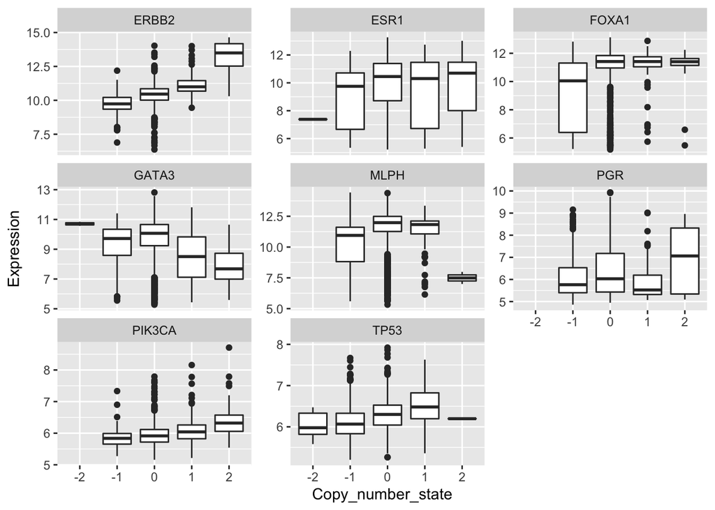

```r
ggplot(data = combined, mapping = aes(x = Copy_number_state, y = Expression)) +
  geom_boxplot() +
  facet_wrap(vars(Gene), scales = "free_y")
```

Customize this plot by changing the labels, scales, colours and theme as you like – be creative!

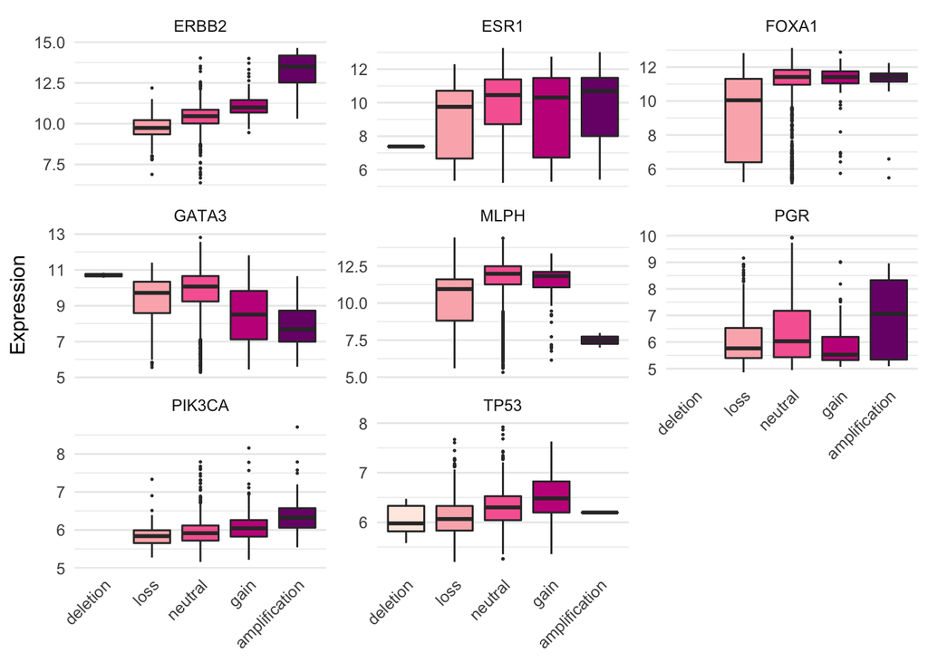

```r
ggplot(data = combined, mapping = aes(x = Copy_number_state, y = Expression, fill = Copy_number_state)) +
  geom_boxplot(outlier.size = 0.2) +
  facet_wrap(vars(Gene), scales = "free_y") +
  labs(x = NULL) +
  scale_x_discrete(labels = c("deletion", "loss", "neutral", "gain", "amplification")) +
  scale_fill_brewer(palette = "RdPu") +
  theme_minimal() +
  theme(
    panel.grid.major.x = element_blank(),
    axis.text.x = element_text(angle = 45, hjust = 1, vjust = 1),
    legend.position = "none"
  )
```

There will be chocolate-based prizes awarded to any assignment handed in with a plot that is prettier than mine – Matt (bear in mind that I’m also the judge and jury).

**5. Extension: Mutual exclusivity of ERBB2 amplifications and AKT1 mutations**

*Seriously, stop here if you haven’t got the time or inclination to attempt this final, bonus extension exercise (but please still hand in your assignment).*

In the METABRIC 2016 paper, Pereira *et al.* ([Nature Communications 7:11479, 2016](https://www.ncbi.nlm.nih.gov/pubmed/27161491)) considered the association between somatic mutations, exploring patterns of co-mutation and mutual exclusivity. One of their findings was the mutual exclusivity between AKT1 mutations and amplification of ERBB2. For the final exercise we will reproduce this observation.

We’ll first need to read the mutation data into R and we’re only interested in those cases where the patient tumour sample was sequenced so we’ll read those in as well.

```r
mutations <- read_csv("metabric_mutations.csv")
cases_sequenced <- read_tsv("cases_nat_comm_2016.txt", col_names = "Patient_ID")
```

Filter the mutations table to only contain the non-silent mutations in AKT1.

```r
akt1_mutations <- mutations %>%
  filter(Gene == "AKT1", Variant_Classification != "Silent")
```

Add a logical column to the `cases_sequenced` data frame called `AKT1_mutated` that indicates whether there was a non-silent AKT1 mutation detected in each patient tumour sample.

Count the number of patients with and without a non-silent AKT1 mutation.

```r
cases_sequenced <- cases_sequenced %>%
  mutate(AKT1_mutated = Patient_ID %in% akt1_mutations$Patient_ID)
count(cases_sequenced, AKT1_mutated)
```

```
## # A tibble: 2 x 2
##   AKT1_mutated     n
##   <lgl>        <int>
## 1 FALSE         2333
## 2 TRUE           100
```

*Hint: use a `mutate()` with `%in%`.*

Filter the copy number states table to only include entries for ERBB2.

Count the number of samples for each ERBB2 copy number state.

```r
erbb2_copy_number_states <- copy_number_states %>%
  filter(Hugo_Symbol == "ERBB2") %>%
  select(Sample, ERBB2_copy_number_state = Copy_number_state)
count(erbb2_copy_number_states, ERBB2_copy_number_state)
```

```
## # A tibble: 4 x 2
##   ERBB2_copy_number_state     n
##   <fct>                   <int>
## 1 -1                        378
## 2 0                        1270
## 3 1                         183
## 4 2                         342
```

Join the ERBB2 copy number state table to the table we created before identifying which patient has an AKT1 mutation. The combined data frame should only contain entries for patients that have been sequenced and for which copy number data are available.

```r
erbb2_akt1_association <- inner_join(cases_sequenced, erbb2_copy_number_states, by = c("Patient_ID" = "Sample"))
erbb2_akt1_association
```

```
## # A tibble: 2,097 x 3
##    Patient_ID AKT1_mutated ERBB2_copy_number_state
##    <chr>      <lgl>        <fct>
##  1 MB-0000    FALSE        0
##  2 MB-0002    FALSE        -1
##  3 MB-0005    FALSE        0
##  4 MB-0006    FALSE        0
##  5 MB-0008    FALSE        0
##  6 MB-0010    FALSE        -1
##  7 MB-0014    FALSE        0
##  8 MB-0022    FALSE        -1
##  9 MB-0025    FALSE        2
## 10 MB-0028    FALSE        1
## # … with 2,087 more rows
```

Count the numbers of patients with different combinations of ERBB2 copy number state and mutated AKT1.

```r
count(erbb2_akt1_association, ERBB2_copy_number_state, AKT1_mutated)
```

```
## # A tibble: 8 x 3
##   ERBB2_copy_number_state AKT1_mutated     n
##   <fct>                   <lgl>        <int>
## 1 -1                      FALSE          355
## 2 -1                      TRUE            21
## 3 0                       FALSE         1155
## 4 0                       TRUE            62
## 5 1                       FALSE          174
## 6 1                       TRUE             2
## 7 2                       FALSE          327
## 8 2                       TRUE             1
```

Does this reflect the observation of mutual exclusivity of ERBB2 amplification and AKT1 mutations?

Create a logical column called `ERBB2_amplified` indicated which patient samples have amplifications (copy number state 2) in ERBB2.

```r
erbb2_akt1_association <- mutate(erbb2_akt1_association, ERBB2_amplified = ERBB2_copy_number_state == 2)
erbb2_akt1_association
```

```
## # A tibble: 2,097 x 4
##    Patient_ID AKT1_mutated ERBB2_copy_number_state ERBB2_amplified
##    <chr>      <lgl>        <fct>                   <lgl>
##  1 MB-0000    FALSE        0                       FALSE
##  2 MB-0002    FALSE        -1                      FALSE
##  3 MB-0005    FALSE        0                       FALSE
##  4 MB-0006    FALSE        0                       FALSE
##  5 MB-0008    FALSE        0                       FALSE
##  6 MB-0010    FALSE        -1                      FALSE
##  7 MB-0014    FALSE        0                       FALSE
##  8 MB-0022    FALSE        -1                      FALSE
##  9 MB-0025    FALSE        2                       TRUE
## 10 MB-0028    FALSE        1                       FALSE
## # … with 2,087 more rows
```

Create a 2-by-2 contingency table using `table()` and the `AKT1_mutated` and `ERBB2_amplified` columns.

```r
contingency_table <- erbb2_akt1_association %>%
  select(ERBB2_amplified, AKT1_mutated) %>%
  table()
contingency_table
```

```
##                AKT1_mutated
## ERBB2_amplified FALSE TRUE
##           FALSE  1684   85
##           TRUE    327    1
```

Perform a Fisher exact test on this contingency table.

```r
fisher.test(contingency_table)
```

```
##
##  Fisher's Exact Test for Count Data
##
## data:  contingency_table
## p-value = 1.128e-05
## alternative hypothesis: true odds ratio is not equal to 1
## 95 percent confidence interval:
##  0.001515843 0.349760112
## sample estimates:
## odds ratio
## 0.06061971
```